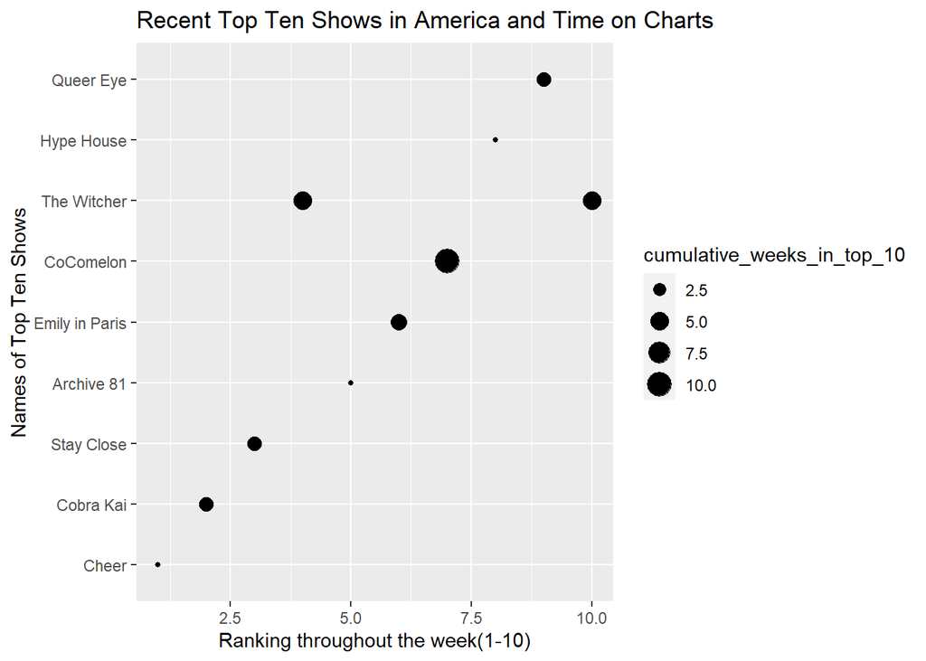

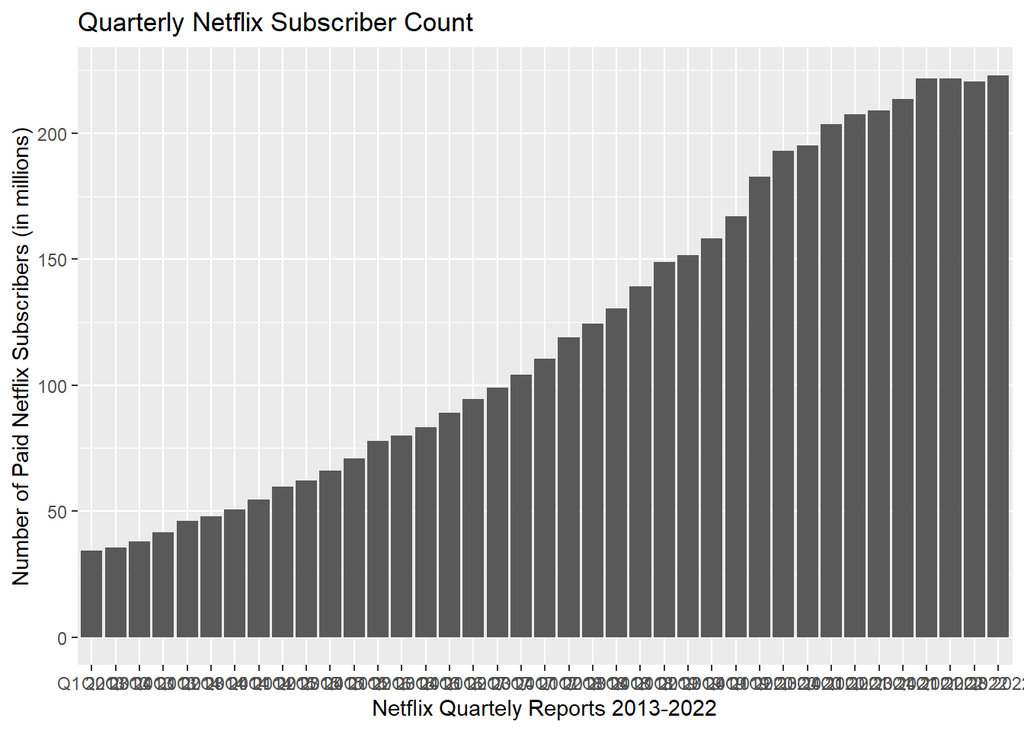

##### The purpose of the chart is to highlight the growth of Netflix’s subscriber count over the years. (Quarter 1 2013 - Quarter 3 2022) This shows an economic growth that the company follows which will help us further our scope of data that we have included in our project to ultimately support our claim that Netflix has had a major socioeconomic impact on the world today. It’s hard to disagree with this claim purely based on the sheer growth and volume of subscribers which we can see in the chart above.

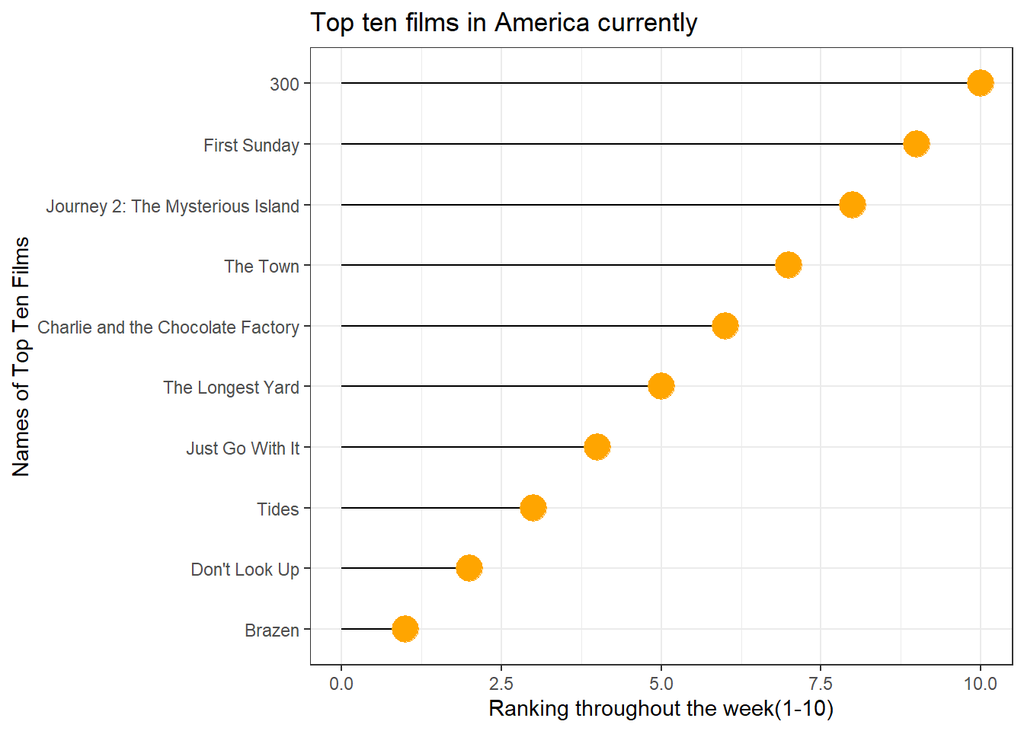

##### We decided to include the graph because it gives us data regarding the most recent week in the data set. With the most recent date we filtered to show the top ten films in the United States, and each film’s ranking that week. It is important to understand how far the dataset goes and current statistics so that we can provide insight to people who want to know more about Netflix, or for people who just want to find a movie they would like to start.

# Aggregated Table

| Content type | Name | cumulative_weeks_in_top_10 |
| --- | --- | --- |
| TV | CoComelon | 305 |
| TV | Manifest | 83 |
| TV | Squid Game | 66 |
| TV | Maid | 55 |
| Films | Vivo | 45 |
| Films | Red Notice | 36 |
| TV | All American | 32 |
| TV | The Witcher | 30 |
| TV | You | 30 |
| TV | The Queen of Flow | 28 |
| TV | Outer Banks | 25 |
| Films | The Holiday | 21 |
| TV | Clickbait | 21 |
| TV | Virgin River | 19 |
| TV | Money Heist | 16 |
| Films | Home | 15 |
| Films | My Little Pony: A New Generation | 15 |
| TV | Emily in Paris | 13 |
| TV | Lost in Space | 13 |
| Films | Don’t Look Up | 10 |
| Films | The Unforgivable | 10 |
| Films | Back to the Outback | 10 |
| Films | The Shack | 10 |
| Films | A Boy Called Christmas | 10 |
| Films | The Harder They Fall | 10 |
| Films | Love Hard | 10 |
| TV | Narcos: Mexico | 10 |
| Films | Titanic | 10 |
| TV | Midnight Mass | 10 |
| TV | The Circle | 10 |

[output cut: 189 more lines]

##### We included this table because it displays important information about the datasets we used. It reveals information about the most popular content on Netflix, such as which shows and films were in the Top 10 on Netflix and for how long.